# Lecture 4 - EDA

## Typical values

Oldschool values are available by useing summary on a dataset or just one variable

```r
summary(diamonds)
```

```
##      carat               cut        color        clarity
##  Min.   :0.2000   Fair     : 1610   D: 6775   SI1    :13065
##  1st Qu.:0.4000   Good     : 4906   E: 9797   VS2    :12258
##  Median :0.7000   Very Good:12082   F: 9542   SI2    : 9194
##  Mean   :0.7979   Premium  :13791   G:11292   VS1    : 8171
##  3rd Qu.:1.0400   Ideal    :21551   H: 8304   VVS2   : 5066
##  Max.   :5.0100                     I: 5422   VVS1   : 3655
##                                     J: 2808   (Other): 2531
##      depth           table           price             x
##  Min.   :43.00   Min.   :43.00   Min.   :  326   Min.   : 0.000
##  1st Qu.:61.00   1st Qu.:56.00   1st Qu.:  950   1st Qu.: 4.710
##  Median :61.80   Median :57.00   Median : 2401   Median : 5.700
##  Mean   :61.75   Mean   :57.46   Mean   : 3933   Mean   : 5.731
##  3rd Qu.:62.50   3rd Qu.:59.00   3rd Qu.: 5324   3rd Qu.: 6.540
##  Max.   :79.00   Max.   :95.00   Max.   :18823   Max.   :10.740
##
##        y                z
##  Min.   : 0.000   Min.   : 0.000
##  1st Qu.: 4.720   1st Qu.: 2.910
##  Median : 5.710   Median : 3.530
##  Mean   : 5.735   Mean   : 3.539
##  3rd Qu.: 6.540   3rd Qu.: 4.040
##  Max.   :58.900   Max.   :31.800
##
```

```r
summary(diamonds$cut)
```

```
##      Fair      Good Very Good   Premium     Ideal
##      1610      4906     12082     13791     21551
```

Use `skimr::skim` to get quick textual info about your variables

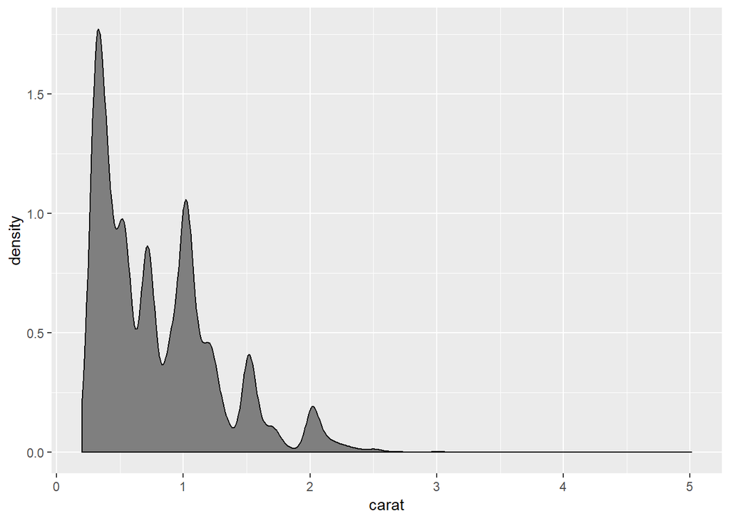

```r
ggplot(diamonds) +
  aes(x = carat) +
  geom_density(fill = "grey50")
```

Unusual values

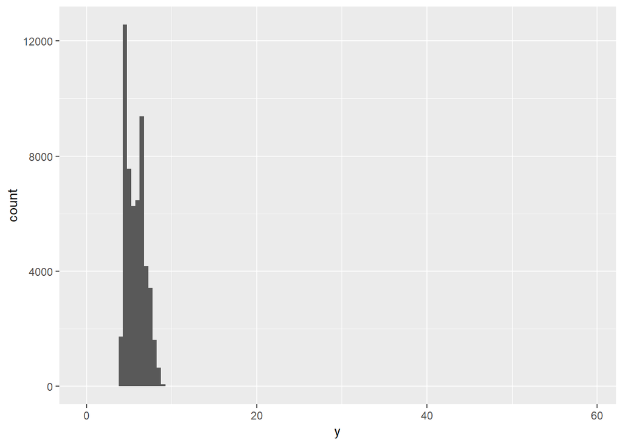

```r
ggplot(diamonds) +
  aes(x = y) +
  geom_histogram(binwidth = 0.5)
```

To make it easy to see the unusual values, we need to zoom to small values of the y-axis with `coord_cartesian()`

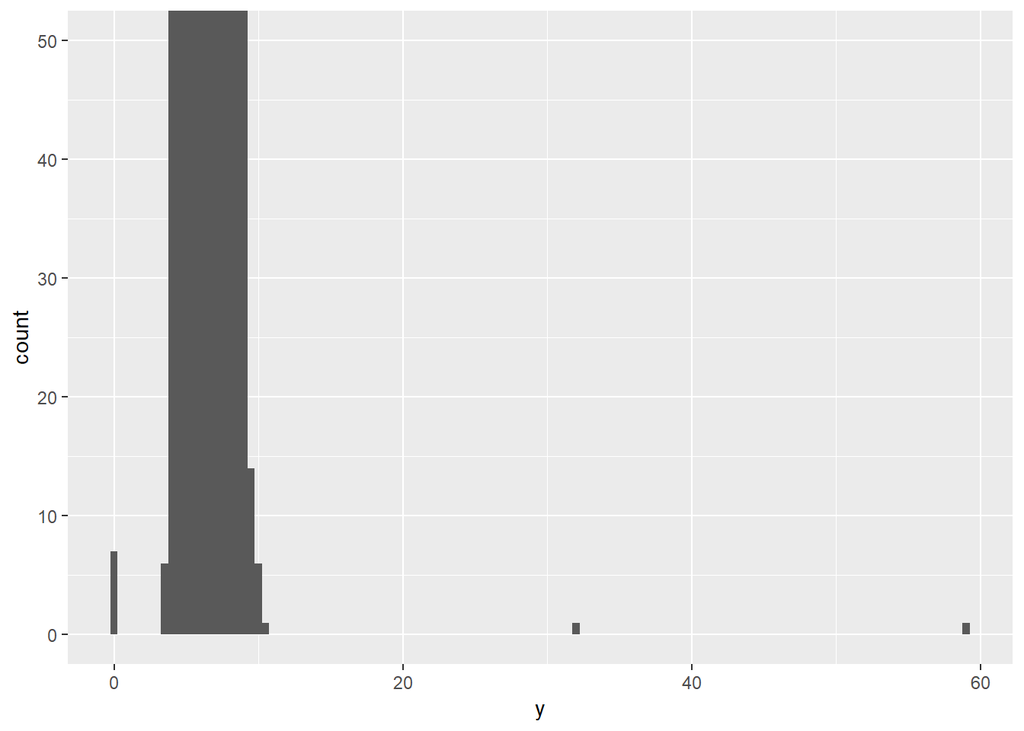

```r
ggplot(diamonds) +
  aes(x = y) +
  geom_histogram(binwidth = 0.5) +
  coord_cartesian(ylim = c(0, 50))
```

Let’s save the unusual values that are smaller than 3 and larger than 20. Let’s check the unusual values.

```r
unusual <-
  diamonds %>%
  filter(y < 3 | y > 20) %>%
  select(price, x, y, z) %>%
  arrange(y)

unusual
```

```
## # A tibble: 9 x 4
##   price     x     y     z
##   <int> <dbl> <dbl> <dbl>
## 1  5139  0      0    0
## 2  6381  0      0    0
## 3 12800  0      0    0
## 4 15686  0      0    0
## 5 18034  0      0    0
## 6  2130  0      0    0
## 7  2130  0      0    0
## 8  2075  5.15  31.8  5.12
## 9 12210  8.09  58.9  8.06
```

There are diamons that have no size. This looks like an error. Instead of excluding the variables entirely, let’s just make the outlier values `NA` This way, you keep the other values of the observation, that may not be invalid. Also, you don’t have to make note somewhere else that you actually had to remove cases. This information remains in your data.

Missing values will be always shown as a warning

```
## Warning: Removed 9 rows containing missing values (geom_point).
```

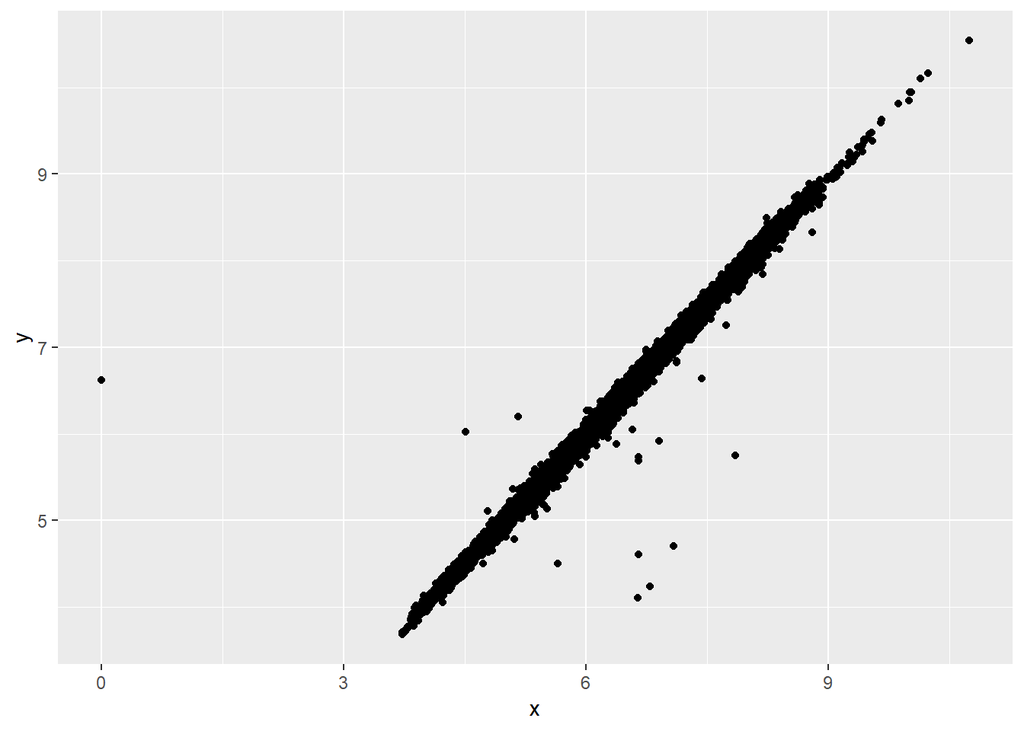

```r
diamonds2 <-
  diamonds %>%
  mutate(y = if_else(y < 3 | y > 20, NA_real_, y))

ggplot(diamonds2) +
  aes(x = x, y = y) +
  geom_point()
```